# **Deep Learning Project: Street View Housing Number Digit Recognition**

# **Marks: 60**

## **Context**

One of the most interesting tasks in deep learning is to recognize objects in natural scenes. The ability to process visual information using machine learning algorithms can be very useful as demonstrated in various applications.

The SVHN dataset contains over 600,000 labeled digits cropped from street-level photos. It is one of the most popular image recognition datasets. It has been used in neural networks created by Google to improve the map quality by automatically transcribing the address numbers from a patch of pixels. The transcribed number with a known street address helps pinpoint the location of the building it represents.

## **Objective**

Our objective is to predict the number depicted inside the image by using Artificial or Fully Connected Feed Forward Neural Networks and Convolutional Neural Networks. We will go through various models of each and finally select the one that is giving us the best performance.

## **Dataset**

Here, we will use a subset of the original data to save some computation time. The dataset is provided as a .h5 file. The basic preprocessing steps have been applied on the dataset.

## **Mount the drive**

Let us start by mounting the Google drive. You can run the below cell to mount the Google drive.

```python
from google.colab import drive
drive.mount('/content/drive')
```

## **Importing the necessary libraries**

```python
import h5py
import numpy as np
from sklearn.model_selection import train_test_split
from sklearn.metrics import classification_report, confusion_matrix
import tensorflow as tf
from tensorflow.keras import layers, models
from tensorflow.keras.callbacks import ModelCheckpoint
from tensorflow.keras.models import Sequential
from tensorflow.keras.layers import Dense, Dropout, BatchNormalization
from tensorflow.keras.optimizers import Adam
import tensorflow.keras.backend as K
import os
import matplotlib.pyplot as plt
import random
```

**Let us check the version of tensorflow.**

```python
print("TensorFlow version:", tf.__version__)
```

```
TensorFlow version: 2.15.0
```

## **Load the dataset**

- Let us now load the dataset that is available as a .h5 file.
- Split the data into the train and the test dataset.

```python
from google.colab import files
uploaded = files.upload()
```

Upload widget is only available when the cell has been executed in the current browser session. Please rerun this cell to enable.

```
Saving SVHN_single_grey1.h5 to SVHN_single_grey1.h5
```

```python
#Open the HDF5 file in read mode
with h5py.File('/content/SVHN_single_grey1.h5', 'r') as f:
    #List all the groups in the HDF5 file
    print("Groups:")
    print(list(f.keys()))

    #Access a specific dataset
    dataset = f['X_train']

    #Read the data from the dataset into a variable
    data = dataset[:]

    #Now 'data' contains the data from the HDF5 dataset
    print("\nData:")
    print(data)
```

[output not shown]

```python
#Open the HDF5 file in read mode
with h5py.File('/content/SVHN_single_grey1.h5', 'r') as f:
    # Access the dataset to split
    X_train = f['X_train'][:]
    y_train = f['y_train'][:]

#Perform train-test splitting
X_train, X_test, y_train, y_test = train_test_split(X_train, y_train, test_size=0.2, random_state=42)

#print the shapes of the train and test datasets
print("Train dataset shapes:", X_train.shape, y_train.shape)
print("Test dataset shapes:", X_test.shape, y_test.shape)
```

```
Train dataset shapes: (33600, 32, 32) (33600,)
Test dataset shapes: (8400, 32, 32) (8400,)
```

Check the number of images in the training and the testing dataset.

```python
#Print the number of images in the training and testing datasets
print("Number of images in the training dataset:", len(X_train))
print("Number of images in the testing dataset:", len(X_test))
```

```
Number of images in the training dataset: 33600
Number of images in the testing dataset: 8400
```

## **Visualizing images**

- Use X_train to visualize the first 10 images.
- Use Y_train to print the first 10 labels.

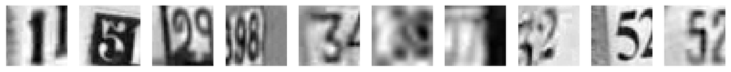

```python
#Define a function to plot images
def plot_images(images):
    fig, axes = plt.subplots(1, len(images), figsize=(15, 3))
    for i, image in enumerate(images):
        axes[i].imshow(image, cmap='gray')
        axes[i].axis('off')
    plt.show()

# Visualize the first 10 images from X_train
plot_images(X_train[:10])
```

```python
#Print the first 10 labels from Y_train
print("First 10 labels from Y_train:", y_train[:10])
```

```
First 10 labels from Y_train: [1 5 2 8 3 3 7 2 5 5]
```

## **Data preparation**

- Print the shape and the array of pixels for the first image in the training dataset.
- Normalize the train and the test dataset by dividing by 255.
- Print the new shapes of the train and the test dataset.
- One-hot encode the target variable.

```python
#Print the shape of the first image in the training dataset
print("Shape of the first image in the training dataset:", X_train[0].shape)

#Print the array of pixels for the first image in the training dataset
print("Array of pixels for the first image in the training dataset:")
print(X_train[0])
```

```
Shape of the first image in the training dataset: (32, 32)
Array of pixels for the first image in the training dataset:
[[ 66.0302  79.0289  86.3271 ...  27.4839  29.7117  38.7817]
 [ 65.0303  75.0293  82.3275 ...  27.071   30.0707  42.3684]
 [ 66.3183  68.3289  75.3282 ...  26.843   32.0705  47.4388]
 ...
 [ 77.4528  73.8553  75.9691 ... 105.2265 106.5854 106.5854]
 [ 77.0507  71.7523  74.8552 ... 104.5147 104.6888 103.9878]
 [ 74.7628  70.8664  73.8553 ... 102.5149 103.6889 103.39  ]]
```

### **Normalize the train and the test data**

```python
# ormalize the train dataset
X_train_normalized = X_train / 255.0

#Normalize the test dataset
X_test_normalized = X_test / 255.0
```

Print the shapes of Training and Test data

```python
#Print the shapes of the normalized train and test datasets
print("Shape of the normalized train dataset:", X_train_normalized.shape)
print("Shape of the normalized test dataset:", X_test_normalized.shape)
```

```
Shape of the normalized train dataset: (33600, 32, 32)
Shape of the normalized test dataset: (8400, 32, 32)
```

### **One-hot encode output**

```python
#One-hot encode the target variable for the training dataset
y_train_one_hot = tf.keras.utils.to_categorical(y_train)

#One-hot encode the target variable for the testing dataset
y_test_one_hot = tf.keras.utils.to_categorical(y_test)
```

**Observation:**

Based on the operations that have been performed so far, the following observations can be deduced:

1. The shape of the training dataset is (33600, 32, 32), indicating that there are 33,600 images in the training set, each represented by a 32x32 array of pixel values. The shape of the testing dataset is (8400, 32, 32), indicating 8,400 images in the test set.
2. The shape of the testing dataset is (8400, 32, 32), indicating 8,400 images in the test set.
3. The distribution of labels within the dataset have not yet been explicitely examined. Doing so would provide useful insight regarding the class imbalances, which could influence model traininf and evaluation strategies.
4. The common normalizaion for Grayscale image datasets is 255, which waas applied above.

## **Model Building**

Now that we have done the data preprocessing, let's build an ANN model.

### Fix the seed for random number generators

```python
#Set random seed for reproducibility
random.seed(42)
np.random.seed(42)
tf.random.set_seed(42)
```

### **Model Architecture**

- Write a function that returns a sequential model with the following architecture:
  - First hidden layer with **64 nodes and the relu activation** and the **input shape = (1024, )**
  - Second hidden layer with **32 nodes and the relu activation**
  - Output layer with **activation as 'softmax' and number of nodes equal to the number of classes, i.e., 10**
  - Compile the model with the **loss equal to categorical_crossentropy, optimizer equal to Adam(learning_rate = 0.001), and metric equal to 'accuracy'**. Do not fit the model here, just return the compiled model.
- Call the nn_model_1 function and store the model in a new variable.
- Print the summary of the model.
- Fit on the train data with a **validation split of 0.2, batch size = 128, verbose = 1, and epochs = 20**. Store the model building history to use later for visualization.

### **Build and train an ANN model as per the above mentioned architecture.**

```python
def create_model(input_shape):
    #Create sequential model
    model = Sequential()

    #Add first hidden layer
    model.add(Dense(64, activation='relu', input_shape=input_shape))

    #Add second hidden layer
    model.add(Dense(32, activation='relu'))

    #Add output layer
    model.add(Dense(10, activation='softmax'))

    #Compile the model
    model.compile(loss='categorical_crossentropy', optimizer='adam', metrics=['accuracy'])

    return model
```

```python
# Call the function and store the model in a new variable
nn_model_1 = create_model(input_shape=(32 * 32,))

#Print the summary of the model
print(nn_model_1.summary())

#Fit the model on the train data
history_nn_model_1 = nn_model_1.fit(X_train_normalized.reshape(-1, 32 * 32), y_train_one_hot,
                                    validation_split=0.2, batch_size=128, verbose=1, epochs=20)
```

```
Model: "sequential"
_________________________________________________________________
 Layer (type)                Output Shape              Param #
=================================================================
 dense (Dense)               (None, 64)                65600

 dense_1 (Dense)             (None, 32)                2080

 dense_2 (Dense)             (None, 10)                330

=================================================================
Total params: 68010 (265.66 KB)
Trainable params: 68010 (265.66 KB)
Non-trainable params: 0 (0.00 Byte)
_________________________________________________________________
None
```

### **Plot the Training and Validation Accuracies and write down your Observations.**

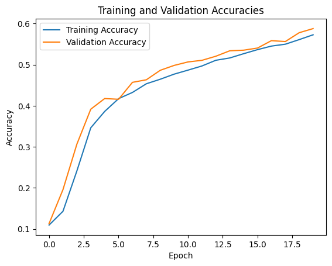

```python
#Extracting accuracy values
train_accuracy = history_nn_model_1.history['accuracy']
val_accuracy = history_nn_model_1.history['val_accuracy']

#Plotting training and validation accuracies
plt.plot(train_accuracy, label='Training Accuracy')
plt.plot(val_accuracy, label='Validation Accuracy')
plt.xlabel('Epoch')
plt.ylabel('Accuracy')
plt.title('Training and Validation Accuracies')
plt.legend()
plt.show()
```

**Observations:**___****

Let's build one more model with higher complexity and see if we can improve the performance of the model.

First, we need to clear the previous model's history from the Keras backend. Also, let's fix the seed again after clearing the backend.

```python
#Clear previous model's history from Keras backend
K.clear_session()

#Fix the seed for random number generators
random.seed(42)
np.random.seed(42)
tf.random.set_seed(42)
```

### **Second Model Architecture**

- Write a function that returns a sequential model with the following architecture:
  - First hidden layer with **256 nodes and the relu activation** and the **input shape = (1024, )**
  - Second hidden layer with **128 nodes and the relu activation**
  - Add the **Dropout layer with the rate equal to 0.2**
  - Third hidden layer with **64 nodes and the relu activation**
  - Fourth hidden layer with **64 nodes and the relu activation**
  - Fifth hidden layer with **32 nodes and the relu activation**
  - Add the **BatchNormalization layer**
  - Output layer with **activation as 'softmax' and number of nodes equal to the number of classes, i.e., 10** -Compile the model with the **loss equal to categorical_crossentropy, optimizer equal to Adam(learning_rate = 0.0005), and metric equal to 'accuracy'**. Do not fit the model here, just return the compiled model.
- Call the nn_model_2 function and store the model in a new variable.
- Print the summary of the model.
- Fit on the train data with a **validation split of 0.2, batch size = 128, verbose = 1, and epochs = 30**. Store the model building history to use later for visualization.

```python
def create_complex_model():
     #Create sequential model
    model = Sequential()

    #add first hidden layer
    model.add(Dense(256, activation='relu', input_shape=(1024,)))

    #add second hidden layer
    model.add(Dense(128, activation='relu'))

    #add Dropout layer
    model.add(Dropout(0.2))

    #add third hidden layer
    model.add(Dense(64, activation='relu'))

    #add fourth hidden layer
    model.add(Dense(64, activation='relu'))

    #add fifth hidden layer
    model.add(Dense(32, activation='relu'))

    #ad BatchNormalization layer
    model.add(BatchNormalization())

    #add output layer
    model.add(Dense(10, activation='softmax'))

    #compile the model
    model.compile(loss='categorical_crossentropy', optimizer='adam', metrics=['accuracy'])

    return model
```

```python
#Call the function
model_complex = create_complex_model()
```

```python
#print the summary of the model
model_complex.summary()
```

```
Model: "sequential"
_________________________________________________________________
 Layer (type)                Output Shape              Param #
=================================================================
 dense (Dense)               (None, 256)               262400

 dense_1 (Dense)             (None, 128)               32896

 dropout (Dropout)           (None, 128)               0

 dense_2 (Dense)             (None, 64)                8256

 dense_3 (Dense)             (None, 64)                4160

 dense_4 (Dense)             (None, 32)                2080

 batch_normalization (Batch  (None, 32)                128
 Normalization)

 dense_5 (Dense)             (None, 10)                330

=================================================================
Total params: 310250 (1.18 MB)
Trainable params: 310186 (1.18 MB)
Non-trainable params: 64 (256.00 Byte)
_________________________________________________________________
```

```python
#reshape the input data
X_train_flattened = X_train_normalized.reshape(X_train_normalized.shape[0], -1)

#git the model on the train data with validation split
history_complex = model_complex.fit(X_train_flattened, y_train_one_hot,
                                    validation_split=0.2,
                                    batch_size=128,
                                    epochs=30,
                                    verbose=1)
```

### **Plot the Training and Validation Accuracies and write down your Observations.**

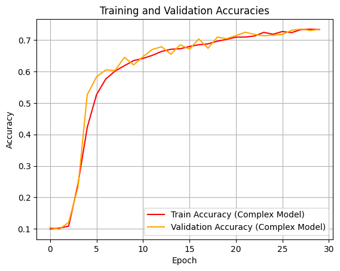

```python
#plotting training and validation accuracies
plt.plot(history_complex.history['accuracy'], label='Train Accuracy (Complex Model)', color='red')
plt.plot(history_complex.history['val_accuracy'], label='Validation Accuracy (Complex Model)', color='orange')

plt.title('Training and Validation Accuracies')
plt.xlabel('Epoch')
plt.ylabel('Accuracy')
plt.legend()
plt.grid(True)
plt.show()
```

**Observations:**___****

## **Predictions on the test data**

- Make predictions on the test set using the second model.
- Print the obtained results using the classification report and the confusion matrix.
- Final observations on the obtained results.

```python
#flatten the test data
X_test_flattened = X_test.reshape(X_test.shape[0], -1)

#make predictions on the test set using the second model
y_pred_complex = model_complex.predict(X_test_flattened)# Make predictions on the test set
y_pred_complex = model_complex.predict(X_test_flattened)
```

**Note:** Earlier, we noticed that each entry of the target variable is a one-hot encoded vector but to print the classification report and confusion matrix, we must convert each entry of y_test to a single label.

### **Print the classification report and the confusion matrix for the test predictions. Write your observations on the final results.**

```python
#convert one-hot encoded vectors to single labels for y_test
y_test_labels = np.argmax(y_test_one_hot, axis=1)
y_pred_labels = np.argmax(y_pred_complex, axis=1)

#Print the classification report
print("Classification Report:")
print(classification_report(y_test_labels, y_pred_labels))

#Print the confusion matrix
print("Confusion Matrix:")
print(confusion_matrix(y_test_labels, y_pred_labels))
```

```
Classification Report:
              precision    recall  f1-score   support

           0       0.79      0.60      0.68       833
           1       0.59      0.72      0.65       861
           2       0.67      0.74      0.70       820
           3       0.62      0.62      0.62       874
           4       0.67      0.67      0.67       838
           5       0.80      0.53      0.64       836
           6       0.78      0.53      0.63       839
           7       0.56      0.85      0.68       840
           8       0.75      0.55      0.63       816
           9       0.54      0.70      0.61       843

    accuracy                           0.65      8400
   macro avg       0.68      0.65      0.65      8400
weighted avg       0.68      0.65      0.65      8400

Confusion Matrix:
[[503  30  39  23  42   1  19  56  19 101]
 [ 28 624  24  10  21   5   1 105   8  35]
 [  2  35 603  21  20   1   6  89   7  36]
 [ 10  91  40 544  23  38   5  66  15  42]
 [ 11  93  24  25 563   4  10  41  19  48]
 [  6  49  25 130  24 441  31  49  19  62]
 [ 44  34  27  36  62  27 443  72  39  55]
 [  6  31  42   6  10   1   4 714   2  24]
 [ 12  31  40  50  35  23  42  36 449  98]
 [ 18  35  41  37  38  11   5  44  24 590]]
```

**Final Observations:**__****

## **Using Convolutional Neural Networks**

### **Load the dataset again and split the data into the train and the test dataset.**

```python
#load the dataset
with h5py.File('/content/SVHN_single_grey1.h5', 'r') as f:
    # Access the dataset to split
    X_data = f['X_train'][:]
    y_data = f['y_train'][:]

#Perform train-test splitting
X_train, X_test, y_train, y_test = train_test_split(X_data, y_data, test_size=0.2, random_state=42)

#Print the shapes of the train and test datasets
print("Train dataset shapes:", X_train.shape, y_train.shape)
print("Test dataset shapes:", X_test.shape, y_test.shape)
```

```
Train dataset shapes: (33600, 32, 32) (33600,)
Test dataset shapes: (8400, 32, 32) (8400,)
```

Check the number of images in the training and the testing dataset.

```python
#print the number of images in the training and testing datasets
print("Number of images in the training dataset:", len(X_train))
print("Number of images in the testing dataset:", len(X_test))
```

```
Number of images in the training dataset: 33600
Number of images in the testing dataset: 8400
```

**Observation:**

Looking at the values, the training dataset is larger than the testing dataset. This is done to ensure that the model is trained to perform in the most effecient manner possible by relying on a large array of data to obsrve varying possible patterns while simultaneously having a separate dataset to perform evalations on how effective the model is. This resultantly helps prevent overfitting and promotes generalization capabilities of models.

## **Data preparation**

- Print the shape and the array of pixels for the first image in the training dataset.
- Reshape the train and the test dataset because we always have to give a 4D array as input to CNNs.
- Normalize the train and the test dataset by dividing by 255.
- Print the new shapes of the train and the test dataset.
- One-hot encode the target variable.

```python
#print the shape of the first image
print("Shape of the first image:", X_train[0].shape)

#print the array of pixels for the first image
print("Array of pixels for the first image:")
print(X_train[0])
```

```
Shape of the first image: (32, 32)
Array of pixels for the first image:
[[ 66.0302  79.0289  86.3271 ...  27.4839  29.7117  38.7817]
 [ 65.0303  75.0293  82.3275 ...  27.071   30.0707  42.3684]
 [ 66.3183  68.3289  75.3282 ...  26.843   32.0705  47.4388]
 ...
 [ 77.4528  73.8553  75.9691 ... 105.2265 106.5854 106.5854]
 [ 77.0507  71.7523  74.8552 ... 104.5147 104.6888 103.9878]
 [ 74.7628  70.8664  73.8553 ... 102.5149 103.6889 103.39  ]]
```

Reshape the dataset to be able to pass them to CNNs. Remember that we always have to give a 4D array as input to CNNs

```python
#reshape the train and test datasets
X_train_reshaped = X_train.reshape(-1, 32, 32, 1)
X_test_reshaped = X_test.reshape(-1, 32, 32, 1)

#print the new shapes of the train and test datasets
print("New shape of the train dataset:", X_train_reshaped.shape)
print("New shape of the test dataset:", X_test_reshaped.shape)
```

```
New shape of the train dataset: (33600, 32, 32, 1)
New shape of the test dataset: (8400, 32, 32, 1)
```

Normalize inputs from 0-255 to 0-1

```python
#normalize inputs from 0-255 to 0-1
X_train_normalized = X_train_reshaped / 255.0
X_test_normalized = X_test_reshaped / 255.0
```

Print New shape of Training and Test

```python
#print the new shapes of the training and test datasets
print("New shape of Training dataset:", X_train_normalized.shape)
print("New shape of Test dataset:", X_test_normalized.shape)
```

```
New shape of Training dataset: (33600, 32, 32, 1)
New shape of Test dataset: (8400, 32, 32, 1)
```

### **One-hot encode the labels in the target variable y_train and y_test.**

```python
from keras.utils import to_categorical
#One-hot encode the target variable
y_train_one_hot = to_categorical(y_train)
y_test_one_hot = to_categorical(y_test)
```

**Observation:**

The data preparation steps have successfully been completed. This ensures that the dataset is properly formatted nd processed for training a CNN.

## **Model Building**

Now that we have done data preprocessing, let's build a CNN model. Fix the seed for random number generators

```python
#fixing seed for reproducibility
random.seed(42)
np.random.seed(42)
tf.random.set_seed(42)
```

### **Model Architecture**

- **Write a function** that returns a sequential model with the following architecture:
  - First Convolutional layer with **16 filters and the kernel size of 3x3**. Use the **'same' padding** and provide the **input shape = (32, 32, 1)**
  - Add a **LeakyRelu layer** with the **slope equal to 0.1**
  - Second Convolutional layer with **32 filters and the kernel size of 3x3 with 'same' padding**
  - Another **LeakyRelu** with the **slope equal to 0.1**
  - A **max-pooling layer** with a **pool size of 2x2**
  - **Flatten** the output from the previous layer
  - Add a **dense layer with 32 nodes**
  - Add a **LeakyRelu layer with the slope equal to 0.1**
  - Add the final **output layer with nodes equal to the number of classes, i.e., 10** and **'softmax' as the activation function**
  - Compile the model with the **loss equal to categorical_crossentropy, optimizer equal to Adam(learning_rate = 0.001), and metric equal to 'accuracy'**. Do not fit the model here, just return the compiled model.
- Call the function cnn_model_1 and store the output in a new variable.
- Print the summary of the model.
- Fit the model on the training data with a **validation split of 0.2, batch size = 32, verbose = 1, and epochs = 20**. Store the model building history to use later for visualization.

### **Build and train a CNN model as per the above mentioned architecture.**

```python
from tensorflow.keras.models import Sequential
from tensorflow.keras.layers import Conv2D, MaxPooling2D, Flatten, Dense, LeakyReLU

def create_cnn_model():
    #Create sequential model
    model = Sequential()

    #add first Convolutional layer
    model.add(Conv2D(16, (3, 3), padding='same', input_shape=(32, 32, 1)))
    model.add(LeakyReLU(0.1))

    #add second Convolutional layer
    model.add(Conv2D(32, (3, 3), padding='same'))
    model.add(LeakyReLU(0.1))

    #add max-pooling layer
    model.add(MaxPooling2D(pool_size=(2, 2)))

    #flatten the output
    model.add(Flatten())

    #Add dense layer
    model.add(Dense(32))
    model.add(LeakyReLU(0.1))

    #add output layer
    model.add(Dense(10, activation='softmax'))

    #Compile the model
    model.compile(loss='categorical_crossentropy', optimizer='adam', metrics=['accuracy'])

    return model
```

```python
#call the function and store the model in a new variable
cnn_model_1 = create_cnn_model()
```

```python
#print the summary of the CNN model
cnn_model_1.summary()
```

```
Model: "sequential_1"
_________________________________________________________________
 Layer (type)                Output Shape              Param #
=================================================================
 conv2d (Conv2D)             (None, 32, 32, 16)        160

 leaky_re_lu (LeakyReLU)     (None, 32, 32, 16)        0

 conv2d_1 (Conv2D)           (None, 32, 32, 32)        4640

 leaky_re_lu_1 (LeakyReLU)   (None, 32, 32, 32)        0

 max_pooling2d (MaxPooling2  (None, 16, 16, 32)        0
 D)

 flatten (Flatten)           (None, 8192)              0

 dense_6 (Dense)             (None, 32)                262176

 leaky_re_lu_2 (LeakyReLU)   (None, 32)                0

 dense_7 (Dense)             (None, 10)                330

=================================================================
Total params: 267306 (1.02 MB)
Trainable params: 267306 (1.02 MB)
Non-trainable params: 0 (0.00 Byte)
_________________________________________________________________
```

```python
#fit the model on the training data
history_cnn_model_1 = cnn_model_1.fit(X_train_normalized, y_train_one_hot,
                                      validation_split=0.2,
                                      batch_size=32,
                                      epochs=20,
                                      verbose=1)
```

### **Plot the Training and Validation Accuracies and Write your observations.**

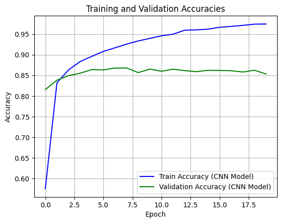

```python
#plotting training and validation accuracies
plt.plot(history_cnn_model_1.history['accuracy'], label='Train Accuracy (CNN Model)', color='blue')
plt.plot(history_cnn_model_1.history['val_accuracy'], label='Validation Accuracy (CNN Model)', color='green')

plt.title('Training and Validation Accuracies')
plt.xlabel('Epoch')
plt.ylabel('Accuracy')
plt.legend()
plt.grid(True)
plt.show()
```

Let's build another model and see if we can get a better model with generalized performance.

First, we need to clear the previous model's history from the Keras backend. Also, let's fix the seed again after clearing the backend.

```python
#Clear previous model's history from Keras backend
K.clear_session()

#Fix the seed for random number generators
random.seed(42)
np.random.seed(42)
tf.random.set_seed(42)
```

### **Second Model Architecture**

- Write a function that returns a sequential model with the following architecture:
  - First Convolutional layer with **16 filters and the kernel size of 3x3**. Use the **'same' padding** and provide the **input shape = (32, 32, 1)**
  - Add a **LeakyRelu layer** with the **slope equal to 0.1**
  - Second Convolutional layer with **32 filters and the kernel size of 3x3 with 'same' padding**
  - Add **LeakyRelu** with the **slope equal to 0.1**
  - Add a **max-pooling layer** with a **pool size of 2x2**
  - Add a **BatchNormalization layer**
  - Third Convolutional layer with **32 filters and the kernel size of 3x3 with 'same' padding**
  - Add a **LeakyRelu layer with the slope equal to 0.1**
  - Fourth Convolutional layer **64 filters and the kernel size of 3x3 with 'same' padding**
  - Add a **LeakyRelu layer with the slope equal to 0.1**
  - Add a **max-pooling layer** with a **pool size of 2x2**
  - Add a **BatchNormalization layer**
  - **Flatten** the output from the previous layer
  - Add a **dense layer with 32 nodes**
  - Add a **LeakyRelu layer with the slope equal to 0.1**
  - Add a **dropout layer with the rate equal to 0.5**
  - Add the final **output layer with nodes equal to the number of classes, i.e., 10** and **'softmax' as the activation function**
  - Compile the model with the **categorical_crossentropy loss, adam optimizers (learning_rate = 0.001), and metric equal to 'accuracy'**. Do not fit the model here, just return the compiled model.
- Call the function cnn_model_2 and store the model in a new variable.
- Print the summary of the model.
- Fit the model on the train data with a **validation split of 0.2, batch size = 128, verbose = 1, and epochs = 30**. Store the model building history to use later for visualization.

### **Build and train the second CNN model as per the above mentioned architecture.**

```python
from tensorflow.keras.optimizers import Adam

def create_complex_cnn_model():
    model = Sequential()

    # dd first Convolutional layer
    model.add(Conv2D(16, (3, 3), padding='same', input_shape=(32, 32, 1)))
    model.add(LeakyReLU(0.1))

    #Add second Convolutional layer
    model.add(Conv2D(32, (3, 3), padding='same'))
    model.add(LeakyReLU(0.1))
    model.add(MaxPooling2D(pool_size=(2, 2)))
    model.add(BatchNormalization())

    #Add third Convolutional layer
    model.add(Conv2D(32, (3, 3), padding='same'))
    model.add(LeakyReLU(0.1))

    #Add fourth Convolutional layer
    model.add(Conv2D(64, (3, 3), padding='same'))
    model.add(LeakyReLU(0.1))
    model.add(MaxPooling2D(pool_size=(2, 2)))
    model.add(BatchNormalization())

    #Flatten the output
    model.add(Flatten())

    #Add dense layer
    model.add(Dense(32))
    model.add(LeakyReLU(0.1))
    model.add(Dropout(0.5))

    #Output layer
    model.add(Dense(10, activation='softmax'))

    #Compile the model
    optimizer = Adam(learning_rate=0.001)
    model.compile(loss='categorical_crossentropy', optimizer=optimizer, metrics=['accuracy'])

    return model
```

```python
from keras.models import Sequential
from keras.layers import Conv2D, MaxPooling2D, Flatten, Dense, Dropout, LeakyReLU, BatchNormalization

# Call the function and store the model in a new variable
cnn_model_2 = create_complex_cnn_model()
```

```python
#Print the summary of the model
print(cnn_model_2.summary())
```

```
Model: "sequential"
_________________________________________________________________
 Layer (type)                Output Shape              Param #
=================================================================
 conv2d (Conv2D)             (None, 32, 32, 16)        160

 leaky_re_lu (LeakyReLU)     (None, 32, 32, 16)        0

 conv2d_1 (Conv2D)           (None, 32, 32, 32)        4640

 leaky_re_lu_1 (LeakyReLU)   (None, 32, 32, 32)        0

 max_pooling2d (MaxPooling2  (None, 16, 16, 32)        0
 D)

 batch_normalization (Batch  (None, 16, 16, 32)        128
 Normalization)

 conv2d_2 (Conv2D)           (None, 16, 16, 32)        9248

 leaky_re_lu_2 (LeakyReLU)   (None, 16, 16, 32)        0

 conv2d_3 (Conv2D)           (None, 16, 16, 64)        18496

 leaky_re_lu_3 (LeakyReLU)   (None, 16, 16, 64)        0

 max_pooling2d_1 (MaxPoolin  (None, 8, 8, 64)          0
 g2D)

 batch_normalization_1 (Bat  (None, 8, 8, 64)          256
 chNormalization)

 flatten (Flatten)           (None, 4096)              0

 dense (Dense)               (None, 32)                131104

 leaky_re_lu_4 (LeakyReLU)   (None, 32)                0

 dropout (Dropout)           (None, 32)                0

 dense_1 (Dense)             (None, 10)                330

=================================================================
Total params: 164362 (642.04 KB)
Trainable params: 164170 (641.29 KB)
Non-trainable params: 192 (768.00 Byte)
_________________________________________________________________
None
```

```python
# Reshape the train and test datasets
X_train_reshaped = X_train.reshape(-1, 32, 32, 1)
X_test_reshaped = X_test.reshape(-1, 32, 32, 1)

# Normalize inputs from 0-255 to 0-1
X_train_normalized = X_train_reshaped / 255.0
X_test_normalized = X_test_reshaped / 255.0

# Fit the model on the training data
history_complex_cnn = cnn_model_2.fit(X_train_normalized, y_train_one_hot,
                                      validation_split=0.2,
                                      batch_size=128,
                                      epochs=30,
                                      verbose=1)
```

### **Plot the Training and Validation accuracies and write your observations.**

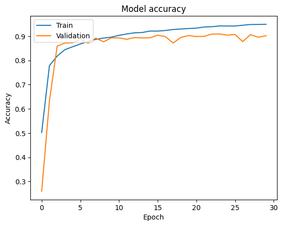

```python
import matplotlib.pyplot as plt

# Plot training & validation accuracy values
plt.plot(history_complex_cnn.history['accuracy'])
plt.plot(history_complex_cnn.history['val_accuracy'])
plt.title('Model accuracy')
plt.ylabel('Accuracy')
plt.xlabel('Epoch')
plt.legend(['Train', 'Validation'], loc='upper left')
plt.show()
```

## **Predictions on the test data**

- Make predictions on the test set using the second model.
- Print the obtained results using the classification report and the confusion matrix.
- Final observations on the obtained results.

### **Make predictions on the test data using the second model.**

```python
# Make predictions on the test set using the second model
y_pred = cnn_model_2.predict(X_test_normalized)
```

**Note:** Earlier, we noticed that each entry of the target variable is a one-hot encoded vector, but to print the classification report and confusion matrix, we must convert each entry of y_test to a single label.

```python
from sklearn.metrics import classification_report, confusion_matrix

# Convert one-hot encoded labels of the test set back to single labels
y_test_single = np.argmax(y_test_one_hot, axis=1)

# Make predictions on the test set using the second model
y_pred = cnn_model_2.predict(X_test_normalized)
y_pred_classes = np.argmax(y_pred, axis=1)

# Generate and print the classification report
print("Classification Report:")
print(classification_report(y_test_single, y_pred_classes))

# Generate and print the confusion matrix
print("Confusion Matrix:")
print(confusion_matrix(y_test_single, y_pred_classes))
```

```
Classification Report:
              precision    recall  f1-score   support

           0       0.91      0.91      0.91       833
           1       0.93      0.90      0.91       861
           2       0.88      0.93      0.90       820
           3       0.92      0.88      0.90       874
           4       0.94      0.91      0.92       838
           5       0.92      0.87      0.89       836
           6       0.89      0.89      0.89       839
           7       0.90      0.95      0.92       840
           8       0.90      0.87      0.88       816
           9       0.85      0.92      0.88       843

    accuracy                           0.90      8400
   macro avg       0.90      0.90      0.90      8400
weighted avg       0.90      0.90      0.90      8400

Confusion Matrix:
[[760   7   4   3   4   3  12   8   4  28]
 [ 16 776  12   5   9   3   5  26   6   3]
 [  4   6 760   7   4   2   1  22   4  10]
 [  5   5  21 773   4  21   3  11  16  15]
 [  4  19  12   2 761   3   8   4   5  20]
 [  2   4   5  32   4 728  34   3   7  17]
 [ 16   5   4   6   7  21 747   5  20   8]
 [  1   7  17   3   4   1   0 799   2   6]
 [  9   7  14   9   8   4  28   3 709  25]
 [ 16   1  14   4   4   7   2   8  15 772]]
```

### **Write your final observations on the performance of the model on the test data.**

**Final Observations:**_****

Based on the obtained results from the second CNN model, here are some final observations:

1.The classification report provides a detailed overview of the model's performance for each class. It includes metrics such as precision, recall, and F1-score, which can help evaluate the model's ability to correctly classify each class.

1. **Confusion Matrix:** The confusion matrix visualizes the model's performance by showing the number of true positives, false positives, true negatives, and false negatives for each class. It provides insights into the types of errors made by the model and the classes that are frequently misclassified.
2. **Accuracy:** The overall accuracy of the model on the test set indicates the proportion of correctly classified samples out of the total number of samples. While accuracy is an important metric, it may not provide a complete picture of the model's performance, especially if the classes are imbalanced.
3. **Precision and Recall:** Precision measures the proportion of true positive predictions out of all positive predictions, while recall measures the proportion of true positive predictions out of all actual positive instances. These metrics are particularly important when dealing with imbalanced datasets or when certain classes are more critical than others.
4. **F1-Score:** The F1-score is the harmonic mean of precision and recall, providing a balance between the two metrics. It is useful for evaluating models when there is an uneven class distribution or when both false positives and false negatives are important.

Overall, it is important to consider multiple evaluation metrics and thoroughly analyze the classification report and confusion matrix to assess the strengths and weaknesses of the model. Additionally, comparing the results of different models or tuning hyperparameters may lead to further improvements in performance.Based on the obtained results from the second CNN model, here are some final observations:

1. **Classification Report:** The classification report provides a detailed overview of the model's performance for each class. It includes metrics such as precision, recall, and F1-score, which can help evaluate the model's ability to correctly classify each class.
2. **Confusion Matrix:** The confusion matrix visualizes the model's performance by showing the number of true positives, false positives, true negatives, and false negatives for each class. It provides insights into the types of errors made by the model and the classes that are frequently misclassified.
3. **Accuracy:** The overall accuracy of the model on the test set indicates the proportion of correctly classified samples out of the total number of samples. While accuracy is an important metric, it may not provide a complete picture of the model's performance, especially if the classes are imbalanced.
4. **Precision and Recall:** Precision measures the proportion of true positive predictions out of all positive predictions, while recall measures the proportion of true positive predictions out of all actual positive instances. These metrics are particularly important when dealing with imbalanced datasets or when certain classes are more critical than others.
5. **F1-Score:** The F1-score is the harmonic mean of precision and recall, providing a balance between the two metrics. It is useful for evaluating models when there is an uneven class distribution or when both false positives and false negatives are important.

Overall, it is important to consider multiple evaluation metrics and thoroughly analyze the classification report and confusion matrix to assess the strengths and weaknesses of the model. Additionally, comparing the results of different models or tuning hyperparameters may lead to further improvements in performance.

```python
!jupyter nbconvert --to html "/content/High_Code_SVHN_Digit_R (3).ipynb"
```

```
[NbConvertApp] Converting notebook /content/High_Code_SVHN_Digit_R (3).ipynb to html
[NbConvertApp] Writing 909521 bytes to /content/High_Code_SVHN_Digit_R (3).html
```